# Desigualdad económica en situaciones de hacinamiento en jóvenes de Chile

Autor/a

Krishna Arce y Valentina Sassi

Fecha de publicación

24 de marzo de 2026

## Introducción

En chile las desigualdades económicas son una brecha significativa en la calidad de vida en los/as jovenes chilenos, donde la poblaciones más ricas son las más priviligiadas. Según Mieres Brevis (2020) desigualdad de Chile es intra e interregional, los ingresos del 20% de la población más rica son 10 veces mayores que los del quintil más pobre (OCDE, 2018), siendo sorprendentemente mayor que el promedio de los países de la OCDE.

Desde una perspectiva historica, se plantea que también los efectos del neoliberalismos han repercutido en desigualdades económicas que afectan a las viviendas, como nos menciona Serey (2023) las políticas de vivienda actuales tienen su origen en la introducción del neoliberalismo durante la dictadura militar y se caracterizan por su focalización en los grupos más vulnerables de la población, por la priorización del régimen de propiedad por encima de otros tipos de tenencia y por el subsidio a la demanda.

En este sentido, esta situación se relaciona con las desigualdes socioeconómicas estructurales presentes en Chile, las cuales han sido influenciadas por el modelo neoliberalista, que presentan factores como el alto costo de la vivienda, nos hace preguntarnos en nuestra investigación, ¿Cómo influyen los ingresos económicos en las situaciónes de hacinamiento en los jovenes de Chile?

A partir de esta problemática, plateamos la siguiente hipótesis: Mientras menores sean los ingresos económicos de los/as jóvenes de Chile, mayores serán las probabilidades de presentar condiciones de hacinamiento habitacional, debido a las limitaciones económicas para acceder a viviendas adecuadas. Mientras que menores sean los ingresos económicos de los/as jóvenes en Chile, mayores serán las probabilidades de presentar condiciones de hacinamiento habitacional, debido a las limitaciones económicas para acceder a viviendas adecuadas.

Para esto, definiremos las variables; En primer lugar, la variable independiente está hace referencia hacia los ingresos del hogar, como el total de ingresos percibidos. En segundo lugar, la variable dependiente siendo el hacinamiento crítico, que se refiere según el Censo del año 2024 (2024) , el hacinamiento se produce cuando residen 2,5 personas o más en promedio por dormitorio en una vivienda. El hacinamiento puede clasificarse en hacinamiento medio y hacinamiento crítico.

Para el análisis de datos, se utilizará la base de datos de la Encuesta de Caracterización Socioeconomica Nacional (CASEN) del año 2022, para identificar las brechas de desigualdad en Chile desde una perspectiva cuantitativa en la relación de las variables de los ingresos y condiciones de vivienda.

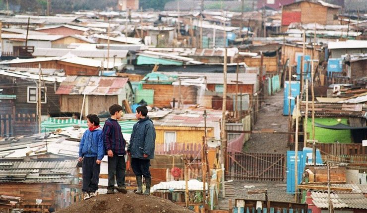

Desigualdades sociales en vivienda

## Objetivo general

Analizar y interpretar la relación entre la desigualdad económica y condiciones de hacinamiento en jóvenes de Chile utilizando datos de la Encuesta CASEN 2022.

## Objetivos específicos

- Operacionalizar variables relacionadas con ingresos, hacinamiento y características sociodemográficas.
- Describir estadísticamente las variables seleccionadas.
- Analizar la asociación entre ingresos económicos y hacinamiento.
- Construir un índice de vulnerabilidad social asociado a condiciones habitacionales.
- Interpretar los resultados obtenidos mediante tablas y visualizaciones.

## Metodología

En nuestra investigación utilizaremos las base de datos de la Casen del año 2022, que nos permite aproximarnos alnalisis de las condiciones socioeconómicas y codiciones habitacionales de la población chilena.

Para esto, se realizará un análisis mediante los software de RStudio y el uso de Quarto para la elaboración de un reporte dinámico. En primer lugar, se filtrara la población del estudio, considerando únicamente los/as jóvenes entre 18 y 29 años de acuerdo a nuestro objeto de estudio.

Posteriormente, en el proceso de operacionalización, se realizara una limpieza de datos, con tratamiento de valores perdidos (NA), la recodificación de variables y ordenamiento de categorías.

Para permitirnos elaborar tablas descriptivas (medidas de tendencia central) y tablas de frecuencia para variables categóricas, en conjunto con gráficos univariados que nos permiten visualizar la distribución de las variables principales.

## R Analisis de Datos

```r
## preparación de datos

# 1. Cargar Paquetes

#Librerías
library(tidyverse)
library(haven)
library(snakecase)
library(summarytools)
library(dplyr)
library(kableExtra)
library(psych)
library(knitr)
library(corrplot)
# 1.2. Configuración para evitar notación científica
options(scipen = 999)

# 2. Cargar base de datos
casen <- read_sav("C:/Users/shirochifuyu/Downloads/casen_2022.sav")

# 3. Limpiar variables
names(casen) <- make.unique(names(casen))

# 4. Convertir a data.frame

casen <- as.data.frame(casen)

# 5. Filtrar población de jóvenes (18 a 29 años)
cas_jovenes <- casen %>%
  filter(edad >= 18 & edad <= 29) %>%
  # Limpieza de valores perdidos (-88, -99) en variables numéricas
  mutate(across(where(is.numeric), ~na_if(., -88)),
         across(where(is.numeric), ~na_if(., -99)))


# 6. Operalización de variables

cas_jovenes <- cas_jovenes %>%
  mutate(
    # Ingreso: Se mantiene lógica, ytotcor es la variable derivada oficial
    ingreso = if_else(ytotcor > 0, ytotcor, NA_real_),

    # Escolaridad: Basado en años de escolaridad (esc)
    escolaridad = as.numeric(esc),

    # Hacinamiento: Ajuste de precisión según estructura de hogares
    # Se usa v27a para viviendas de un solo hogar y v29a para hogares en viviendas compartidas
    dormitorios_hogar = if_else(is.na(v29a), v27a, v29a),

    hacinamiento_ratio = case_when(
      dormitorios_hogar > 0 ~ tot_per_h / dormitorios_hogar,
      dormitorios_hogar == 0 ~ tot_per_h, # Si no hay piezas, el ratio es el total de personas
      TRUE ~ NA_real_
    ),

    # Categorías de hacinamiento (Estándar MDSN)
    hacinamiento_cat = factor(
      case_when(
        hacinamiento_ratio < 2.5 ~ "Sin hacinamiento",
        hacinamiento_ratio >= 2.5 & hacinamiento_ratio < 5 ~ "Hacinamiento medio",
        hacinamiento_ratio >= 5 ~ "Hacinamiento crítico"
      ),
      levels = c("Sin hacinamiento", "Hacinamiento medio", "Hacinamiento crítico"),
      ordered = TRUE
    ),

    # Sexo: 1: Hombre, 2: Mujer [8]
    sexo_cat = factor(sexo, levels = c(1, 2), labels = c("Hombre", "Mujer")),

    # Pobreza: Categoría de pobreza (1:Extrema, 2:No Extrema, 3:No Pobre)
    pobreza_cat = factor(pobreza, levels = c(1, 2, 3),
                         labels = c("Pobreza extrema", "Pobreza no extrema", "No pobre")),

    # Ocupación: o1 registra si trabajó al menos una hora la semana pasada [9]
    ocupacion = if_else(o1 == 1, 1, 0)
  )
# 7. TABLA DESCRIPTIVA

tabla_desc <- cas_jovenes %>%
  select(
    ingreso,
    escolaridad,
    hacinamiento_ratio,
    edad,
    tot_per_h
  ) %>%
  psych::describe()

print(tabla_desc)
```

```
                   vars     n      mean        sd    median   trimmed       mad
ingreso               1 21061 461383.26 422455.08 400000.00 402296.94 296520.00
escolaridad           2 33867     13.30      2.69     13.00     13.41      1.48
hacinamiento_ratio    3 33967      1.41      0.64      1.33      1.34      0.49
edad                  4 33992     23.49      3.43     23.00     23.49      4.45
tot_per_h             5 33992      3.86      1.59      4.00      3.73      1.48
                      min     max      range  skew kurtosis      se
ingreso            167.00 7500000 7499833.00  3.30    24.38 2910.99
escolaridad          0.00      26      26.00 -1.07     4.67    0.01
hacinamiento_ratio   0.08       8       7.92  1.95     7.52    0.00
edad                18.00      29      11.00  0.01    -1.20    0.02
tot_per_h            1.00      13      12.00  0.99     1.97    0.01
```

Por otra parte, la desviación estándar de **0,64**, nos permite evidenciar las diferencias en las condiciones habitacionales de los hogares, debido a la existencia de casos con mayores niveles de sobreocupación residencial. Mientras que, la cercanía entre la media y la media recortada nos evidencia que no existen valores extremos muy influyentes en esta variable. También, la variable de la edad, con un promedio de **23,49** años y una mediana de **23 años**, nos permite entender que es una distribución bastante homogénea dentro del grupo etario estudiado.

Además de poseer una desviación estándar de **3,43 años** siendo una dispersión moderada, con una población concentrada en el tramo de juventud. Finalmente, en la variable tot_per_h (total de personas en el hogar) con promedio de **3,86** integrantes por hogar y una mediana de **4**personas. Nos evidencia que la mayoría de los/as jóvenes reside en hogares de tamaño medio, con una desviación estándar de **1,59** reflejándonos la diversidad en la composición de los hogares, debido a la existencia de hogares pequeños como hogares más numerosos. Donde, la diferencia es mínima entre el promedio y la media recortada con una distribución estable, sin presencia de valores extremos. En resumen, estas estadísticas descriptivas nos evidencian que la población joven analizada posee importantes desigualdades económicas y habitacionales, mientras que en las variables como la edad y la escolaridad sus distribuciones son más homogéneas. Donde estos antecedentes son relevantes para comprender la construcción del Índice de Vulnerabilidad Social y las distintas dimensiones que afectan las condiciones de vida de la juventud en Chile.

```r
# 8. Tabla de frecuencias de hacinamiento ponderada
# El uso de 'expr' (factor de expansión) es esencial para la representatividad.
tabla_frec_hacina <- cas_jovenes %>%
  filter(!is.na(hacinamiento_cat)) %>%
  count(hacinamiento_cat, wt = expr) %>%
  mutate(porcentaje = round(n / sum(n) * 100, 1))

# Generar la tabla
tabla_frec_hacina %>%
  kable(digits = 1,
        caption = "Distribución de hacinamiento en jóvenes (Población Estimada)",
        col.names = c("Categoría", "Población (N)", "Porcentaje (%)")) %>%
  kable_styling(full_width = FALSE, position = "center")
```

Distribución de hacinamiento en jóvenes (Población Estimada)

| Categoría | Población (N) | Porcentaje (%) |
| --- | --- | --- |
| Sin hacinamiento | 3175853 | 92.0 |
| Hacinamiento medio | 258284 | 7.5 |
| Hacinamiento crítico | 16150 | 0.5 |

**Interpretación**: De acuerdo con los datos presentados, se puede observar que la mayoría de los jóvenes (**92.0%**) se encuentra en una situación “sin hacinamiento”, lo que indica que residen en viviendas con condiciones adecuadas de espacio en relación con el número de ocupantes.

Por otro lado, un **7.5%** de los jóvenes vive en “hacinamiento medio”, es decir, existe una cierta presión sobre el espacio disponible, aunque no alcanza niveles extremos. Esta proporción, aunque minoritaria, representa a más de **258 mil** jóvenes, lo cual es un grupo relevante para políticas de vivienda y bienestar.

Finalmente, un **0.5%** se encuentra en “hacinamiento crítico”, la categoría más severa. Aunque el porcentaje es pequeño, equivale a más de 16 mil jóvenes que enfrentan condiciones muy precarias de espacio, con posibles impactos negativos en su salud, privacidad, rendimiento escolar y convivencia familiar.

En resumen, mientras que la gran mayoría de los jóvenes no presenta problemas de hacinamiento, existe un segmento no despreciable (**8% en total, sumando medio y crítico**) que requiere atención, especialmente el grupo en situación crítica, pues enfrenta las condiciones más desfavorables para su desarrollo.

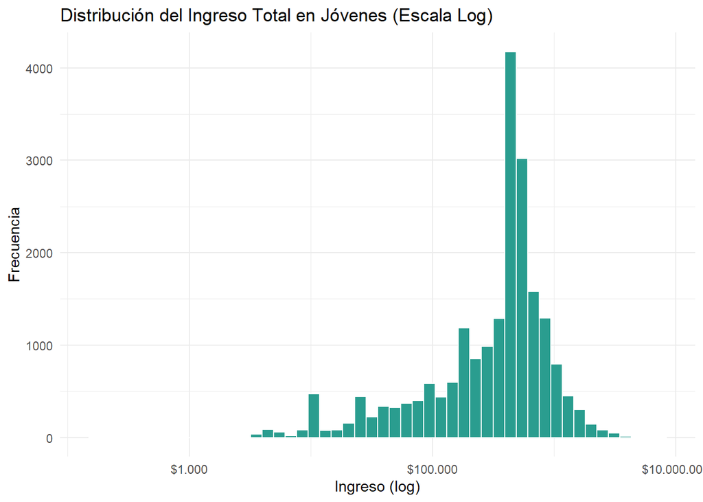

```r
# 9. Gráfico de distribución de ingresos(Univariado)
ggplot(cas_jovenes, aes(x = ingreso)) +
  geom_histogram(fill = "#2a9d8f", color = "white", bins = 50) +
  scale_x_log10(labels = scales::dollar_format(prefix = "$", big.mark = ".")) + # Escala log para visualizar mejor desigualdad
  labs(title = "Distribución del Ingreso Total en Jóvenes (Escala Log)",
       x = "Ingreso (log)", y = "Frecuencia") +
  theme_minimal()
```

Del análisis visual se desprenden los siguientes puntos:

Representatividad: La forma de la distribución valida que el “joven promedio” en Chile habita en hogares con recursos limitados, lo que contrasta con los altos niveles de escolaridad observados en las tablas descriptivas previas.

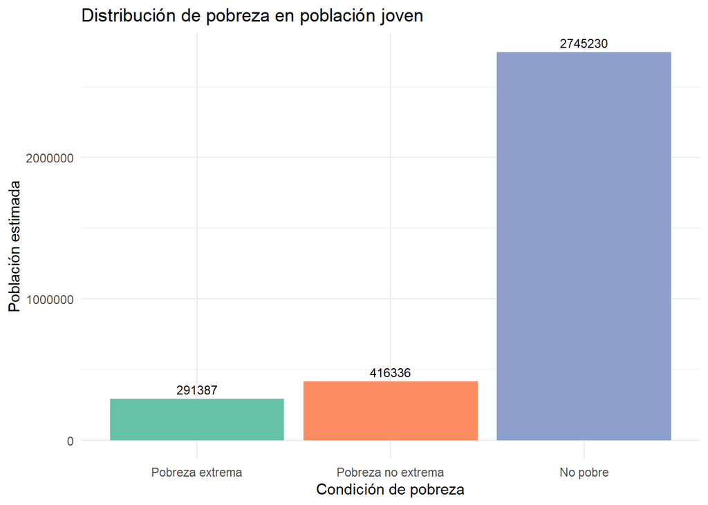

```r
# 10. Gráfico de distribucción de la pobreza (Univariado)
ggplot(
  cas_jovenes %>% filter(!is.na(pobreza_cat)),
  aes(x = pobreza_cat, fill = pobreza_cat)
) +

  geom_bar(aes(weight = expr)) +

  geom_text(
    aes(
      weight = expr,
      label = after_stat(count)
    ),
    stat = "count",
    vjust = -0.5,
    size = 3
  ) +

  scale_fill_brewer(palette = "Set2") +

  labs(
    title = "Distribución de pobreza en población joven",
    x = "Condición de pobreza",
    y = "Población estimada"
  ) +

  theme_minimal() +

  theme(
    legend.position = "none"
  )
```

**Interpretación:** Para comenzar de acuerdo con el gráfico de distribucción de la pobreza de la población joven, nos evidencia que la mayoría se encuentra en la categoría no pobre, en una cifra aproximadamente de **2.745.230** personas,sin embargo, se percibe en una situación de pobreza no extrema de **416.336** personas, mientras que un grupo reducido de **291.387** personas se encuentran en condiciones de pobreza extrema. Reflejandonos que, la mayoría de los/as jovénes presentan condiciones que no son de pobreza al igual que en las situaciones de hacinamiento, se encuentran la mayoría sin hacinamiento. Pero a pesar, de que la mayoría de los/as jovenes no poseen condiciones de pobreza extrema o hacinamiento crítico, se evidencia un segmento de grupos de la población de jovenes que si poseen condiciones de vulnaberidad ecónomica, sobretodo en la diferencia entre la pobreza extrema y no extrema, que es singnificativa,reflejandonos las distintas desigualdades enfretadas por los/as joves de acuerdo a sus niveles de pobreza como hacinamiento, por lo que deberían requerir de la atención de políticas públicas en particulas los grupos que presentan condiciones de hacinamiento crítico como de pobreza extrema.

```r
# 11 . Construcción de Índice de Vulnebaribilidad
# Estandarización Z-score (Z alto = Mayor Vulnerabilidad)

cas_jovenes <- cas_jovenes %>%
  mutate(
    z_hacinamiento = as.numeric(scale(hacinamiento_ratio)),
    z_ingreso      = as.numeric(scale(-ingreso)),
    z_escolaridad  = as.numeric(scale(-escolaridad)),
    # Pobreza: 1=Extrema, 2=No Extrema, 3=No Pobre.
    # El signo negativo asegura que el valor más bajo (extrema) aporte más vulnerabilidad.
    z_pobreza      = as.numeric(scale(-as.numeric(pobreza))),
    z_desempleo    = as.numeric(scale(-ocupacion))
  )

# 12. Calculo de índice de vulnerabilidad social (IVS)

cas_jovenes$indice_vulnerabilidad <- rowMeans(
  cas_jovenes %>% select(z_hacinamiento, z_ingreso, z_escolaridad, z_pobreza, z_desempleo),
  na.rm = TRUE
)

# 13. Alfa de Cronbach (Consistencia Interna)

alpha_indice <- alpha(
  cas_jovenes %>%
    select(z_hacinamiento, z_ingreso, z_escolaridad, z_pobreza, z_desempleo)
)
```

```
Number of categories should be increased  in order to count frequencies.
```

```r
print(alpha_indice)
```

```
Reliability analysis
Call: alpha(x = cas_jovenes %>% select(z_hacinamiento, z_ingreso, z_escolaridad,
    z_pobreza, z_desempleo))

  raw_alpha std.alpha G6(smc) average_r S/N    ase  mean   sd median_r
      0.52      0.53    0.51      0.18 1.1 0.0041 0.019 0.58     0.17

    95% confidence boundaries
         lower alpha upper
Feldt     0.51  0.52  0.53
Duhachek  0.51  0.52  0.53

 Reliability if an item is dropped:
               raw_alpha std.alpha G6(smc) average_r  S/N alpha se  var.r med.r
z_hacinamiento      0.54      0.55    0.51      0.23 1.22   0.0041 0.0163  0.26
z_ingreso           0.36      0.36    0.31      0.12 0.56   0.0057 0.0082  0.13
z_escolaridad       0.47      0.49    0.45      0.19 0.96   0.0047 0.0212  0.18
z_pobreza           0.46      0.46    0.44      0.18 0.85   0.0048 0.0238  0.16
z_desempleo         0.48      0.49    0.43      0.19 0.94   0.0046 0.0066  0.17

 Item statistics
                   n raw.r std.r r.cor r.drop                  mean sd
z_hacinamiento 33967  0.52  0.49  0.23   0.17  0.000000000000000128  1
z_ingreso      21061  0.70  0.71  0.65   0.45 -0.000000000000000029  1
z_escolaridad  33867  0.57  0.57  0.38   0.28 -0.000000000000000153  1
z_pobreza      33985  0.63  0.60  0.42   0.30 -0.000000000000000223  1
z_desempleo    33992  0.55  0.57  0.42   0.26  0.000000000000000091  1
```

**Interpretación:** De acuerdo con los resultados del análisis de consistencia interna , que nos permiten evaluar el grado de coherencia de las variables seleccionadas de la construcción del Índice de Vulnerabilidad Social (IVS). Podemos evidenciar que, las correlaciones de las variables aportan positivamente al índice, aunque con distinta intensidad. En primer lugar, en la variable **z_ingreso**, su asociación es más fuerte con el índice, con un valor de **raw.r = 0,699** y **std.r = 0,713**, indicándonos que el ingreso constituye una de las dimensiones centrales de la vulnerabilidad social, de manera significativa en la consistencia interna del indicador. Además, su correlación corregida (**r.cor = 0,651**) y la correlación del ítem-total (**r.drop = 0,449**) nos permite comprender una relación sólida con el conjunto del índice de la variable.

Por otro lado, la variable **z_pobreza**, es una contribución importante al IVS (**raw.r = 0,626**), evidenciándonos que la condición de pobreza se relaciona de manera consistente con las demás dimensiones de vulnerabilidad. Donde su correlación corregida es de **r.cor = 0,424**, siendo esta esta variable una proporción relevante en la varianza del índice general. También en la variable **z_escolaridad**, con correlaciones moderadas de **raw.r = 0,574**, nos indica la contribución significativa del nivel educativo, pero que es menos intensa que el ingreso o la pobreza. Donde la escolaridad va operando como un recurso estructural que influye indirectamente sobre las oportunidades económicas y laborales de los jóvenes.

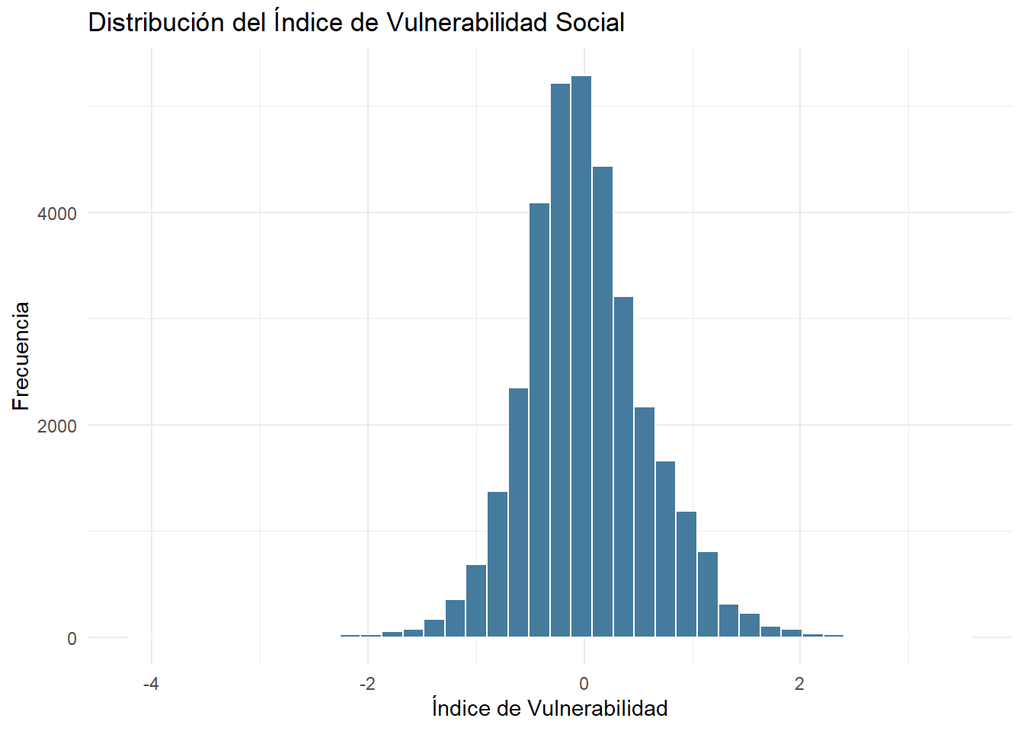

```r
# 14. Gráfico de distriibucción del índice
ggplot(cas_jovenes,
       aes(x = indice_vulnerabilidad)) +

  geom_histogram(
    bins = 40,
    fill = "#457b9d",
    color = "white"
  ) +

  labs(
    title = "Distribución del Índice de Vulnerabilidad Social",
    x = "Índice de Vulnerabilidad",
    y = "Frecuencia"
  ) +

  theme_minimal()
```

**Interpretación:** El histograma del Índice de Vulnerabilidad Social muestra una distribución aproximadamente simétrica y con forma de campana, semejante a una distribución normal. En la cual se observa como la gran mayoría de los jóvenes se concentra en niveles de vulnerabilidad media, con un pico central que supera los **4.000 casos** alrededor del valor **0** del índice estandarizado.

Al ser una distribución simétrica, ambos extremos se comportan de manera equivalente. La cola izquierda, que representa valores negativos del índice y por lo tanto una menor vulnerabilidad o mayor protección social, disminuye de forma gradual a medida que nos alejamos del centro. De igual manera, la cola derecha, que representa valores positivos y una mayor vulnerabilidad social, también disminuye de forma gradual y en proporción similar. Esto significa que hay aproximadamente tantos jóvenes en situación de vulnerabilidad extrema como jóvenes en situación de alta protección social.

Desde una perspectiva social, esta simetría indica que la vulnerabilidad no está sistemáticamente sesgada hacia un lado. Los factores de riesgo y los factores protectores se distribuyen de manera relativamente homogénea en la población juvenil estudiada. Sin embargo, esto no le resta importancia a la cola derecha, ya que los jóvenes con alta vulnerabilidad requieren intervenciones focalizadas a pesar de ser un grupo reducido en términos porcentuales.

Al comparar con el indicador de hacinamiento analizado anteriormente, se observa una diferencia importante. Mientras que el hacinamiento presentaba una distribución muy asimétrica con el **92%** de los jóvenes sin problemas de hacinamiento, el índice de vulnerabilidad social es mucho más equilibrado. Esto se debe a que el índice integra múltiples dimensiones como ingresos, educación, empleo y vivienda, mientras que el hacinamiento es un indicador más específico y concentrado.

En conclusión, la mayoría de los jóvenes se encuentra en un nivel medio de vulnerabilidad, los extremos son pequeños pero equilibrados, y la atención prioritaria debe dirigirse a la cola derecha de alta vulnerabilidad sin descuidar las políticas de prevención para el grupo central.

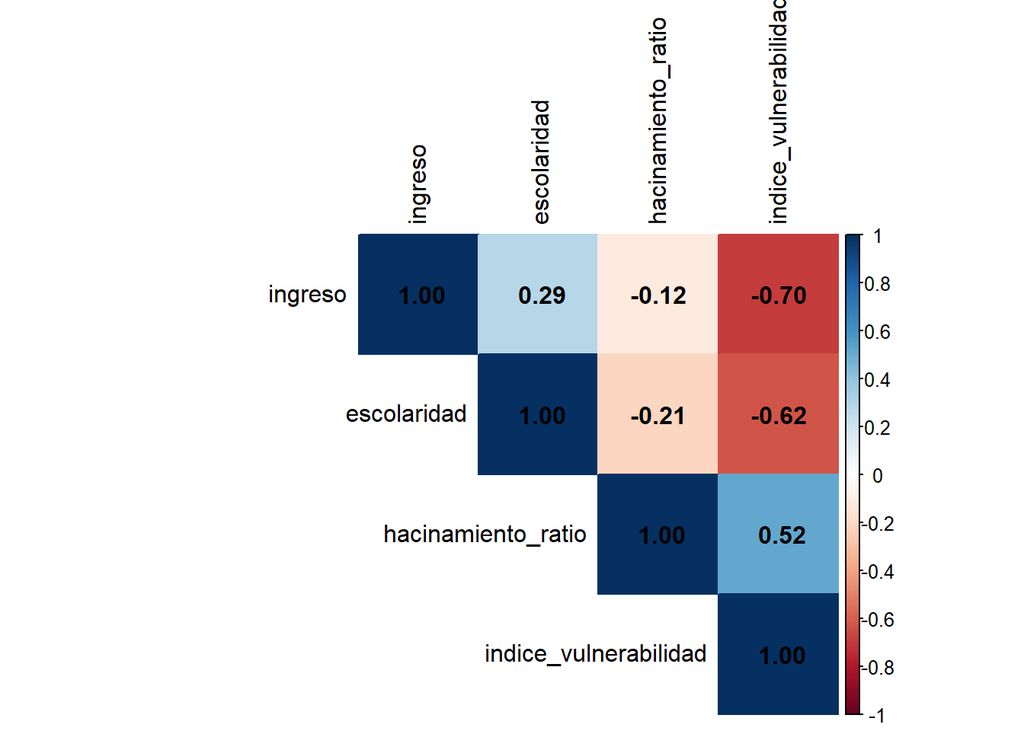

```r
# 15. Matriz de correlaciones
matriz_corr <- cas_jovenes %>%
  select(ingreso, escolaridad, hacinamiento_ratio, indice_vulnerabilidad) %>%
  cor(use = "complete.obs")

# 15.1. Vizualización

corrplot(matriz_corr, method = "color", type = "upper",
         tl.col = "black", addCoef.col = "black")
```

**Interpretación:** De acuerdo con la matriz de correlaciones, nos evidencian relaciones consistentes entre las variables incluidas en el Índice de Vulnerabilidad Social (IVS). En primer lugar, el ingreso y la escolaridad poseen una correlación positiva baja-moderada de **r = 0,29**, indicando que mayores niveles educativos tienden a asociarse con mayores ingresos. Por otro lado, el hacinamiento se relaciona de manera negativa con el ingreso, siendo un resultado de **r = -0,12**, como con la escolaridad en un **r = -0,21**, evidenciándonos que las condiciones habitacionales más vulnerables se concentran en hogares con menores recursos económicos y educativos disponibles. Asimismo, de acuerdo con el índice de vulnerabilidad, se puede evidenciar una correlación negativa fuerte con el ingreso de **r = -0,70** y con la escolaridad con un **r = -0,62**. Donde mientras mayores sean los ingresos y mayor será el nivel educativo, asociado con menores niveles de vulnerabilidad social. En contraste, respecto con el hacinamiento, posee una correlación positiva moderada con el índice en un **r = 0,52**, indicándonos qué las condiciones habitacionales más precarias, pueden aumentar la vulnerabilidad social en los/as jóvenes.

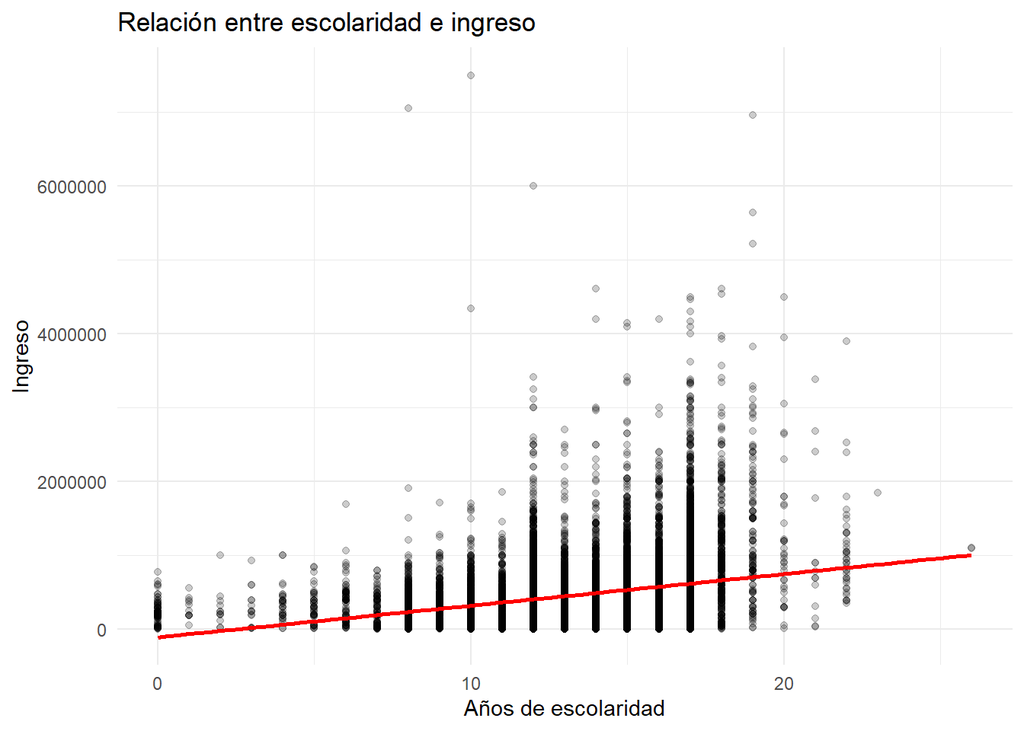

```r
# 16. Gráfico de asociación entre escolaridad e ingreso
 ggplot(
  cas_jovenes,
  aes(x = escolaridad, y = ingreso)
) +

  geom_point(alpha = 0.2) +

  geom_smooth(
    method = "lm",
    se = FALSE,
    color = "red"
  ) +

  labs(
    title = "Relación entre escolaridad e ingreso",
    x = "Años de escolaridad",
    y = "Ingreso"
  ) +

  theme_minimal()
```

En términos generales, se observa una relación positiva entre ambas variables: a mayor cantidad de años de estudio, mayor es el ingreso que perciben los jóvenes. Esto se confirma visualmente por la línea de regresión (de color rojo), que tiene una pendiente ascendente clara.

Sin embargo, el hallazgo técnico más relevante del gráfico es la presencia de heterocedasticidad, es decir, la variabilidad de los ingresos no es constante a lo largo de los años de escolaridad, sino que se abre en forma de abanico a medida que nos desplazamos hacia la derecha. Para niveles bajos de escolaridad, entre **0 y 10 años**, los ingresos están muy comprimidos cerca de la base, cercanos a cero o a salarios mínimos. Tener pocos años de estudio prácticamente garantiza ingresos bajos, con muy pocas excepciones. En cambio, al superar los **12 años** de escolaridad, que suele coincidir con el egreso de la educación secundaria, y especialmente entre los **15 y 20 años**, correspondiente a educación superior, la nube de puntos se dispersa fuertemente hacia arriba. Esto demuestra que la educación superior abre el techo de los ingresos, permitiendo sueldos que pueden superar los dos, cuatro e incluso seis millones de unidades monetarias, pero no los garantiza para todos, ya que también existe una gran cantidad de jóvenes con alta escolaridad que siguen percibiendo ingresos bajos.

Desde una perspectiva social y económica, el gráfico permite extraer tres conclusiones fundamentales. Primero, la educación funciona más como un expansor de oportunidades que como una garantía automática de ingresos altos. Sin educación, el techo de ingresos está blindado a la baja; con educación, el techo se eleva drásticamente, pero el piso sigue estando abajo para muchos. Segundo, se observan concentraciones masivas de jóvenes en hitos institucionales clave, como los **12 años** (egreso de secundaria) y los **17 o 18 años** (egreso de carreras universitarias o técnicas profesionales). Es precisamente en estos hitos donde la desigualdad de ingresos se vuelve más evidente. Tercero, la línea de regresión, aunque útil para mostrar la dirección general de la asociación, puede resultar engañosa porque la masa de datos en la base es gigantesca y la media es estirada hacia arriba por los pocos sueldos millonarios de la cúspide.

En conclusión, para las políticas públicas este gráfico indica que la educación sola no basta. Si bien aumentar los años de escolaridad es clave para dar la posibilidad de salir de la pobreza, el mercado laboral distribuye de forma muy desigual los ingresos entre los jóvenes profesionales. Por lo tanto, se requiere analizar con mayor profundidad qué sucede en la educación superior, incluyendo la calidad de las instituciones y el campo laboral de las carreras elegidas, para entender por qué la dispersión de ingresos es tan brutal en los niveles educativos más altos. Una recomendación adicional sería calcular la mediana del ingreso por cada nivel educativo, ya que esta es menos sensible a los valores extremos y reflejaría mejor la realidad del joven típico de cada grupo de escolaridad.

[figure not shown]

Muchas gracias por su atención

## Referencias

Instituto Nacional de Estadísticas (INE). 2024. «Presentación nacional Censo de Población y Vivienda 2024». https://www.ine.gob.cl/docs/default-source/conferencias/2025/cc-cpv-presentacion-nacional-2024.pdf.

Mieres Brevis, Michelle. 2020. «La Dinamica de La Desigualdad En Chile: Una Mirada Regional». *Revista de Análisis Económico* 35 (2): 91-133. https://doi.org/10.4067/S0718-88702020000200091.

Serey, Claudia. 2023. «El rol del Estado en el aseguramiento del derecho a una vivienda adecuada en Chile». Tesis doctoral. https://repositorio.uchile.cl/bitstream/handle/2250/195811/Tesis%20-%20Claudia%20Serey.pdf?sequence=1&isAllowed=y.